# Quantization of FICO scores with genetic algorithms

A FICO score is a standardized credit score created by the Fair Isaac Corporation (FICO) that quantifies the creditworthiness of a borrower to a value between 300 to 850, based on various factors. FICO scores are used in 90% of mortgage application decisions in the United States.

The objective is to construct a technique for predicting the probability of default for the borrowers using FICO scores and quantizing them into a smaller number of bins.

```python
import pandas as pd
import numpy as np
import matplotlib.pyplot as plt
import pygad
from task4 import Map

plt.rcParams.update({
    'text.usetex': True,
    'font.family': 'serif',
    'font.serif': ['Times New Roman'],
    'figure.titlesize': 16,
    'axes.labelsize': 12,
    'axes.titlesize': 14,
    'xtick.labelsize': 10,
    'ytick.labelsize': 10,
    'axes.grid': True,
    'axes.axisbelow': True,
    'grid.alpha': 0.5,
    'axes.spines.right': False,
    'axes.spines.top': False,
    'figure.figsize': (10, 6),
    'figure.dpi': 100,
})
```

Load the loan book and keep only information about Fico scores and default events.

```python
loan_data = pd.read_csv('loan_data.csv')
loan_data = loan_data[['customer_id', 'fico_score', 'default']]
```

The quantization of FICO scores is done using genetic algorithms, in which the genes are the values of the thresholds that separate the bins. The search is set as a multi-objective optimization problem, where the fitness function accounts for the log-likelihood of the partition, \begin{equation} L \left( \mathbf{b} \right) = \sum_{i=1}^{N} \left[ k_i \log p_i + \left( n_i - k_i \right) \log \left( 1 - p_i \right) \right] \end{equation} and a score that penalizes non-monotonic trends in default rates across the bins.

```python
# Target numer of bins
nbins = 10

# Defining the constraints for the gene space
min_fico = 300
max_fico = 850
for i in range(nbins+1):
    if i == 0:
        gene_space = [min_fico]
    elif i == nbins:
        gene_space.append(max_fico)
    else:
        gene_space.append({'low': min_fico, 'high': max_fico, 'step': 1})
```

```python
# Defining callback function
last_fitness = 0
def on_generation(ga_instance):
    global last_fitness
    with np.printoptions(precision=3, suppress=True):
        print(f"Generation = {ga_instance.generations_completed}, Fitness = {ga_instance.best_solution(pop_fitness=ga_instance.last_generation_fitness)[1]}, Change = {ga_instance.best_solution(pop_fitness=ga_instance.last_generation_fitness)[1] - last_fitness}")
    last_fitness = ga_instance.best_solution(pop_fitness=ga_instance.last_generation_fitness)[1]

# Defining the fitness function
def fitness_fcn(ga_instance, solution, solution_idx):
    bins = np.sort(solution)
    data = loan_data.copy()
    fitness = Map(data).get_log_likelihood(bins, verbose=False)
    return fitness
```

```python
# Create instance of Genetic Algorithm
ga_instance = pygad.GA(
    random_seed=42,
    num_generations=250,
    num_parents_mating=70,
    fitness_func=fitness_fcn,
    sol_per_pop=100,
    num_genes=nbins+1,
    allow_duplicate_genes=False,
    parent_selection_type='nsga2',
    keep_elitism=20,
    crossover_probability=0.9,
    mutation_probability=0.4,
    init_range_low=min_fico,
    init_range_high=max_fico,
    gene_space=gene_space,
    mutation_percent_genes=20,
    on_generation=on_generation
    )

# Run the Genetic Algorithm
ga_instance.run()
```

```
Generation = 1, Fitness = [-4281.797   -96.477], Change = [-4281.797   -96.477]
Generation = 2, Fitness = [-4278.138     3.216], Change = [ 3.659 99.693]
Generation = 3, Fitness = [-4278.138     3.216], Change = [0. 0.]
Generation = 4, Fitness = [-4289.111     3.295], Change = [-10.973   0.079]
Generation = 5, Fitness = [-4276.96      3.479], Change = [12.15   0.184]
Generation = 6, Fitness = [-4262.082     3.502], Change = [14.879  0.023]
Generation = 7, Fitness = [-4311.778     3.504], Change = [-49.696   0.003]
Generation = 8, Fitness = [-4284.482     3.548], Change = [27.296  0.043]
Generation = 9, Fitness = [-4289.2      3.65], Change = [-4.718  0.102]
Generation = 10, Fitness = [-4289.2      3.65], Change = [0. 0.]
Generation = 11, Fitness = [-4289.2      3.65], Change = [0. 0.]
Generation = 12, Fitness = [-4289.2      3.65], Change = [0. 0.]
Generation = 13, Fitness = [-4289.2      3.65], Change = [0. 0.]
Generation = 14, Fitness = [-4289.2      3.65], Change = [0. 0.]
Generation = 15, Fitness = [-4289.2      3.65], Change = [0. 0.]
Generation = 16, Fitness = [-4289.2      3.65], Change = [0. 0.]
Generation = 17, Fitness = [-4289.2      3.65], Change = [0. 0.]
Generation = 18, Fitness = [-4289.2      3.65], Change = [0. 0.]
Generation = 19, Fitness = [-4289.2      3.65], Change = [0. 0.]
Generation = 20, Fitness = [-4289.2      3.65], Change = [0. 0.]
Generation = 21, Fitness = [-4289.2      3.65], Change = [0. 0.]
Generation = 22, Fitness = [-4289.2      3.65], Change = [0. 0.]
Generation = 23, Fitness = [-4289.2      3.65], Change = [0. 0.]
Generation = 24, Fitness = [-4289.2      3.65], Change = [0. 0.]
Generation = 25, Fitness = [-4289.2      3.65], Change = [0. 0.]
Generation = 26, Fitness = [-4289.2      3.65], Change = [0. 0.]
Generation = 27, Fitness = [-4289.2      3.65], Change = [0. 0.]
Generation = 28, Fitness = [-4289.2      3.65], Change = [0. 0.]
Generation = 29, Fitness = [-4289.2      3.65], Change = [0. 0.]
Generation = 30, Fitness = [-4284.194     3.667], Change = [5.005 0.017]
Generation = 31, Fitness = [-4284.194     3.667], Change = [0. 0.]
Generation = 32, Fitness = [-4284.194     3.667], Change = [0. 0.]
Generation = 33, Fitness = [-4284.194     3.667], Change = [0. 0.]
Generation = 34, Fitness = [-4284.194     3.667], Change = [0. 0.]
Generation = 35, Fitness = [-4284.194     3.667], Change = [0. 0.]
Generation = 36, Fitness = [-4284.194     3.667], Change = [0. 0.]
Generation = 37, Fitness = [-4284.194     3.667], Change = [0. 0.]
Generation = 38, Fitness = [-4284.194     3.667], Change = [0. 0.]
Generation = 39, Fitness = [-4284.194     3.667], Change = [0. 0.]
Generation = 40, Fitness = [-4284.194     3.667], Change = [0. 0.]
```

[output cut: 195 more lines]

```
Generation = 236, Fitness = [-4254.886     3.73 ], Change = [0. 0.]
Generation = 237, Fitness = [-4254.886     3.73 ], Change = [0. 0.]
Generation = 238, Fitness = [-4254.886     3.73 ], Change = [0. 0.]
Generation = 239, Fitness = [-4254.886     3.73 ], Change = [0. 0.]
Generation = 240, Fitness = [-4254.886     3.73 ], Change = [0. 0.]
Generation = 241, Fitness = [-4254.886     3.73 ], Change = [0. 0.]
Generation = 242, Fitness = [-4254.886     3.73 ], Change = [0. 0.]
Generation = 243, Fitness = [-4254.886     3.73 ], Change = [0. 0.]
Generation = 244, Fitness = [-4254.886     3.73 ], Change = [0. 0.]
Generation = 245, Fitness = [-4254.886     3.73 ], Change = [0. 0.]
Generation = 246, Fitness = [-4254.886     3.73 ], Change = [0. 0.]
Generation = 247, Fitness = [-4254.886     3.73 ], Change = [0. 0.]
Generation = 248, Fitness = [-4254.886     3.73 ], Change = [0. 0.]
Generation = 249, Fitness = [-4254.886     3.73 ], Change = [0. 0.]
Generation = 250, Fitness = [-4254.886     3.73 ], Change = [0. 0.]
```

```python
solution, solution_fitness, solution_idx = ga_instance.best_solution()
print(f'Solution: {np.sort(solution)}')
print(f'Solution Fitness: {solution_fitness}')
optimized_map = Map(loan_data)
_ = optimized_map.get_log_likelihood(solution)
report = optimized_map.report
report
```

```
Solution: [300. 442. 508. 515. 536. 569. 594. 640. 691. 817. 850.]
Solution Fitness: [-4.25488575e+03  3.72992528e+00]
```

| fico_bucket | default_rate | default_count | total_count | map_log_likelihood | bin_edges | p_score |
| --- | --- | --- | --- | --- | --- | --- |
| 1 | 0.000000 | 0 | 12 | 0.000000 | [817.0, 850.0] | 1.000000 |
| 2 | 0.053514 | 99 | 1850 | -386.156809 | [691.0, 817.0] | 0.231330 |
| 3 | 0.104947 | 314 | 2992 | -1004.766282 | [640.0, 691.0] | 0.226788 |
| 4 | 0.193014 | 536 | 2777 | -1362.296126 | [594.0, 640.0] | 0.296762 |
| 5 | 0.283568 | 302 | 1065 | -635.050696 | [569.0, 594.0] | 0.300922 |
| 6 | 0.384615 | 305 | 793 | -528.358805 | [536.0, 569.0] | 0.317879 |
| 7 | 0.486275 | 124 | 255 | -176.656441 | [515.0, 536.0] | 0.318840 |
| 8 | 0.604167 | 29 | 48 | -32.221729 | [508.0, 515.0] | 0.343354 |
| 9 | 0.676617 | 136 | 201 | -126.508050 | [442.0, 508.0] | 0.269166 |
| 10 | 0.857143 | 6 | 7 | -2.870814 | [300.0, 442.0] | 0.424883 |

The following figure shows the default rates for the bins of FICO scores.

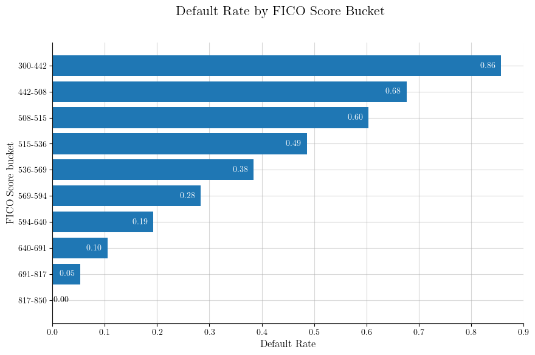

```python
default_rates = report['default_rate'].sort_values(ascending=False)
bin_edges = np.sort(solution)
fig, ax = plt.subplots()
container = ax.barh(default_rates.index, default_rates)
ax.set_xlabel('Default Rate')
ax.set_ylabel('FICO Score bucket')
ax.set_yticks(default_rates.index)
ax.set_yticklabels(labels=[f'{bin_edges[i]:.0f}-{bin_edges[i+1]:.0f}' for i in range(len(bin_edges)-1)])
ann = ax.bar_label(container, fmt='%.2f', padding=-25, color='white')
# Move last annotations to the right
idx = slice(-1, None)
for a in ann[idx]:
    a.set_position((1, 0))
    a.set_color('black')
fig.suptitle('Default Rate by FICO Score Bucket')
plt.show()
```

```python
default_table = pd.DataFrame(index=np.arange(min_fico, max_fico+1,1))
default_table['Bucket'] = pd.cut(default_table.index, bins=bin_edges, labels=range(len(bin_edges)-1, 0, -1), include_lowest=True).astype(int)
default_table['Default Rate'] = report.loc[default_table['Bucket'], 'default_rate'].values
```

The plot below shows the default rates given the FICO scores, according to the optimal quantization found by the genetic algorithm. The default rates are monotonically decreasing with the FICO scores, which is a desirable property for the model.

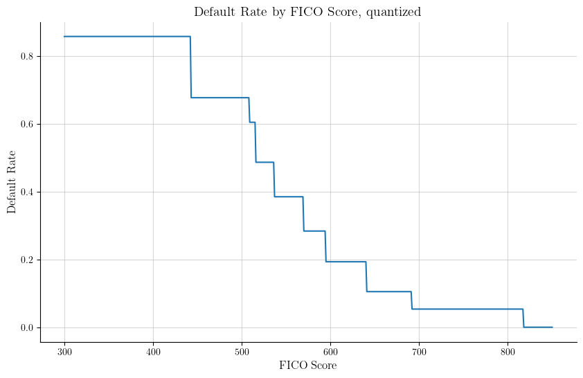

```python
plt.plot(default_table.index, default_table['Default Rate'])
plt.xlabel('FICO Score')
plt.ylabel('Default Rate')
plt.title('Default Rate by FICO Score, quantized')
plt.show()
```